# Bayesian Testing of Equal Genotype Proportions between Multiple Populations

Martin Lysy, Wookjung P. Kim, Terin Robinson

2017-01-15

This tutorial shows how to use the **MADPop** package to test for genetic differences between two populations, of which the individuals of a same species contain a variable number of alleles.

```r
require(MADPop)
```

## Pre-Processing

Our data consists of $N = 215$ recordings of Major Histocompatibility Complex (MHC) genotypes of lake trout from $K = 11$ lakes in Ontario, Canada. For each of the fish, between 1-4 alleles in the MHC genotype are recorded. This is partially because duplicate genes are undetectable by current instrumentation, and possibly because the fish possess a variable number of alleles of a given MHC gene.

Our dataset `fish215` is included with **MADPop**. A random sample from it looks like this:

```r
head(fish215[sample(nObs),])
```

```
##          Lake  A1  A2  A3  A4
## 37     Simcoe t.3         r.4
## 19      Hogan         t.2 r.4
## 49    Crystal         r.1 r.4
## 10      Hogan     r.5 r.4
## 185 Macdonald w.7     w.8
## 163 Kingscote u.4
```

The first column is the lake name (or population ID) for each sample, the remaining four columns are for potentially recorded allele codes (`A1`-`A4`). Here the code to identify a unique allele is a small letter followed by a number, but it could have been the sequence of integers $1, 2,\ldots, A$, which for the `fish215` data is $A = 57$ unique alleles.

It is relatively straightforward to import a CSV file into the format above. An example of this is given along with our raw data in the **extdata** directory of the local copy of the **MADPop** package.

## Two-Population Comparisons

Suppose that we wish to compare two lakes, say Dickey and Simcoe. The allele counts in these lakes are in the table below. It is a subset of the full contingency table on all $K = 11$ lakes, which is produced by the **MADPop** function `UM.suff`:

```r
popId <- c("Dickey", "Simcoe")          # lakes to compare
Xsuff <- UM.suff(fish215)             # summary statistics for dataset
ctab <- Xsuff$tab[popId,]             # contingency table
ctab <- ctab[,colSums(ctab) > 0] # remove alleles with no counts
#ctab
rbind(ctab, Total = colSums(ctab))
```

```
##        1.20 1.4.5 1.4.9.45 1.5 10 20 20.54 27.28.29 3 4 4.10 4.11 4.20.27
## Dickey    1     1        0   2  0  2     1        1 0 0    1    0       1
## Simcoe    0     0        1   1  2  0     0        0 1 1    2    1       0
## Total     1     1        1   3  2  2     1        1 1 1    3    1       1
##        4.20.31 4.20.45 4.27 4.33 4.5 4.53.55 4.56 4.7 4.7.10 5 5.20 5.30
## Dickey       1       1    1    0   1       1    1   0      0 0    1    1
## Simcoe       0       0    0    1   1       0    0   3      1 1    0    0
## Total        1       1    1    1   2       1    1   3      1 1    1    1
##        5.32 5.7 7 9.11
## Dickey    1   1 0    0
## Simcoe    0   1 2    1
## Total     1   2 2    1
```

The unique allele identifiers are encoded as integers between $1$ and $A$ and separated by dots. The original allele names are stored in `Xsuff$A`, such that the genotype of the first column `1.20` is

```r
gtype <- colnames(ctab)[1]
gtype <- as.numeric(strsplit(gtype, "[.]")[[1]])
gtype
```

```
## [1]  1 20
```

```r
names(gtype) <- paste0("A", gtype)
sapply(gtype, function(ii) Xsuff$A[ii])
```

```
##    A1   A20
## "r.1" "u.4"
```

There are $C = 29$ genotype combinations observed in these two lakes, corresponding to each column of the table.

### Multinomial Model

In the two-population problem we have $K = 2$ lakes with $N_1$ and $N_2$ fish sampled from each. Let $\boldsymbol Y_k = (Y_{k1}, \ldots Y_{kC})$ denote the counts for each genotype observed in lake $k$, such that $\sum_{i=1}^C Y_{ki} = N_k$. The sampling model for these data is
$$\boldsymbol Y_k \stackrel{\textrm{ind}}{\sim}\textrm{Multinomial}(N_k, \boldsymbol \rho_k), \quad k = 1,2,$$
where $\boldsymbol \rho_k = (\rho_{k1},...,\rho_{kC})$ are the population proportions of each genotype, and $\sum_{i=1}^C \rho_{ki} = 1$.

### Hypothesis Testing

Our objective is to test
$$\begin{split}
H_0 &: \textrm{The two populations have the same genotype proportions} \\
& \phantom{: } \iff \boldsymbol \rho_1 = \boldsymbol \rho_2.
\end{split}$$
The classical test statistics for assessing $H_0$ are Pearson’s Chi-Square statistic $\mathcal X$ and the Likelihood Ratio statistic $\Lambda$,
$$\mathcal X = \sum_{k=1}^2 \sum_{i=1}^C \frac{(N_k\hat\rho_i - Y_{ki})^2}{N_k\hat\rho_i}, \qquad \Lambda = 2 \sum_{k=1}^2 \sum_{i=1}^C Y_{ki} \log\left(\frac{Y_{ki}}{N_k\hat\rho_i}\right), \qquad \hat \rho_i = \frac{Y_{1i} + Y_{2i}}{N_1 + N_2}.$$
Under $H_0$, the asymptotic distribution of either of these test statistics $T = \mathcal X$ or $\Lambda$ is $\chi^2_{(C-1)}$, such that the $p$-value
$$\textrm{p}_\textrm{v}= \textrm{Pr}(T > T_\textrm{obs} \mid H_0)$$
for an observed value of $T_\textrm{obs}$ can be estimated as follows:

```r
# observed values of the test statistics
chi2.obs <- chi2.stat(ctab) # Pearson's chi^2
LRT.obs <- LRT.stat(ctab) # LR test statistic
T.obs <- c(chi2 = chi2.obs, LRT = LRT.obs)
# p-value with asymptotic calculation
C <- ncol(ctab)
pv.asy <- pchisq(q = T.obs, df = C-1, lower.tail = FALSE)
signif(pv.asy, 2)
```

```
##  chi2   LRT
## 0.330 0.041
```

The Chi-Square and LR tests are asymptotically equivalent and so should give roughly the same $p$-values. The huge discrepancy observed here indicates that the sample sizes are too small for asymptotics to kick in. A more reliable $p$-value estimate can be obtained by the Bootstrap method, which in this case consists of simulating $M$ contigency tables with $\boldsymbol Y_k^{(m)} \stackrel{\textrm{ind}}{\sim}\textrm{Multinomial}(N_k, \hat{\boldsymbol \rho})$, $m = 1, \ldots, M$, where $\hat{\boldsymbol \rho}$ is the estimate of the common probability vector $\boldsymbol \rho_1 = \boldsymbol \rho_2$ under $H_0$. For each contingency table $(\boldsymbol Y_1^{(m)}, \boldsymbol Y_2^{(m)})$, we calculate the test statistic $T^{(m)}$, and the bootstrapped p-value is defined as
$$\textrm{p}_\textrm{v}^{\textrm{boot}}= \frac 1 M \sum_{m=1}^M \delta(T^{(m)} \ge T_\textrm{obs}).$$
$\textrm{p}_\textrm{v}^{\textrm{boot}}$ is calculated with **MADPop** as follows:

```r
N1 <- sum(ctab[1,])                     # size of first sample
N2 <- sum(ctab[2,])                     # size of second sample
rho.hat <- colSums(ctab)/(N1+N2)        # common probability vector
# bootstrap distribution of the test statistics
# set verbose = TRUE for progress output
system.time({
  T.boot <- UM.eqtest(N1 = N1, N2 = N2, p0 = rho.hat, nreps =1e4,
                      verbose = FALSE)
})
```

```
##    user  system elapsed
##   0.719   0.026   0.746
```

```r
# bootstrap p-value
pv.boot <- rowMeans(t(T.boot) >= T.obs)
signif(pv.boot, 2)
```

```
##   chi2    LRT
## 0.0061 0.0056
```

## Pairwise Comparisons between Multiple Populations

Bootstrapping overcomes many deficiencies of the asymptotic $p$-value calculation. However, bootstrapping has a tendency to reject $H_0$ when sample sizes are small. To see why this is, consider all columns of `ctab` which have only one genotype count between the two lakes:

```r
itab1 <- colSums(ctab) == 1             # single count genotypes
cbind(ctab[,itab1],
      Other = rowSums(ctab[,!itab1]),
      Total = rowSums(ctab))
```

```
##        1.20 1.4.5 1.4.9.45 20.54 27.28.29 3 4 4.11 4.20.27 4.20.31 4.20.45
## Dickey    1     1        0     1        1 0 0    0       1       1       1
## Simcoe    0     0        1     0        0 1 1    1       0       0       0
##        4.27 4.33 4.53.55 4.56 4.7.10 5 5.20 5.30 5.32 9.11 Other Total
## Dickey    1    0       1    1      0 0    1    1    1    0     7    20
## Simcoe    0    1       0    0      1 1    0    0    0    1    12    20
```

There are $c_1 = 21$ such columns, accounting for $\hat p_1 = 0.525$ of the common genotype distribution under $H_0$, as estimated from the two-lake sample. For each of these columns, observing counts in one lake but not the other provides evidence against $H_0$. Moreover, under the estimated common distribution $\hat {\boldsymbol \rho}$, it is very unlikely to have counts in only one of the lakes for each of these $c_1 = 21$ genotypes. Therefore, the data appear to provide very strong evidence against $H_0$. However, it is not so unlikely to have $c_1 = 21$ one-count genotypes if the true number of unique genotypes in these two lakes is much larger than the observed value of $C = 29$. With $C = 29$ unique genotypes in only $N = N_1 + N_2 = 40$ fish samples, it is quite plausible that a new sample of fish would yield several genotypes which are not present in the original two-lake sample `ctab`.

One way to obtain information about the unobserved genotypes in lakes Dickey and Simcoe is to consider the genotypes in *all* $K = 11$ Ontario lakes for which we have collected data. A natural way to do this is through a hierarchical model:
$$\begin{split}
\boldsymbol Y_k \mid \boldsymbol \rho_k & \stackrel{\textrm{ind}}{\sim}\textrm{Multinomial}(N_k, \boldsymbol \rho_k), \quad k = 1,\ldots,K \\
\boldsymbol \rho_k & \stackrel{\textrm{iid}}{\sim}\textrm{Dirichlet}(\boldsymbol \alpha), \qquad \boldsymbol \alpha= (\alpha_1, \ldots, \alpha_C).
\end{split}$$
That is, each population is allowed to have its own probability vector $\boldsymbol \rho_k$. However, these probability vectors are drawn from a common Dirichlet distribution. The common distribution specifies that before any data is drawn, we have
$$E[\boldsymbol \rho] = \bar{\boldsymbol \alpha}, \qquad \textrm{var}(\rho_i) = \frac{(\bar \alpha_i)(1-\bar \alpha_i)}{\alpha_0 + 1},$$
where $\alpha_0 = \sum_{i=1}^C \alpha_i$ and $\bar{\boldsymbol \alpha} = \boldsymbol \alpha/ \alpha_0$. Moreover, the posterior distribution of $\boldsymbol \rho_k$ given $\boldsymbol \alpha$ and the data is also Dirichlet:
$$\boldsymbol \rho_k \mid \boldsymbol Y\stackrel{\textrm{ind}}{\sim}\textrm{Dirichlet}(\boldsymbol \alpha+ \boldsymbol Y_k).$$
In this sense, the posterior estimate of the proportion of genotype $i$ in population $k$, $\rho_{ki}$, can be non-zero even if $Y*{ki} = 0$. In practice, $\boldsymbol \alpha$ is estimated from $\boldsymbol Y$, the data from all $K$ populations (details in the following section). The extent to which the genotypes observed in one lake affect inference in the other lakes is determined by $\alpha*0$ (the larger this value, the larger the effect).

### Parameter Estimation

The likelihood function for this model corresponds to a Dirichlet-Multinomial distribution,
$$\begin{split}
\mathcal L(\boldsymbol \alpha\mid \boldsymbol Y) = \prod_{k=1}^K p(\boldsymbol Y_k \mid \boldsymbol \alpha) & = \prod_{k=1}^K \int p(\boldsymbol Y_k \mid \boldsymbol \rho_k) p(\boldsymbol \rho_k \mid \boldsymbol \alpha) \,\mathrm{d}\boldsymbol \rho_k \\
& = \prod_{k=1}^K \left[\frac{N_k!\cdot\Gamma(\alpha_0)}{\Gamma(N_k+\alpha_0)} \prod_{i=1}^C \frac{\Gamma(Y_{ki} + \alpha_i)}{Y_{ki}!\cdot\Gamma(\alpha_i)}\right],
\end{split}$$
from which $\boldsymbol \alpha$ can be estimated by maximum likelihood (Minka 2000). Alternatively we estimate $\boldsymbol \alpha$ using a Bayesian approach, which is more readily extensible to more complex genotype models, for which $\mathcal L(\boldsymbol \alpha\mid \boldsymbol Y)$ has no closed form (see Future Work).

First, we specify a prior distribution
$$\pi(\alpha_0, \bar{\boldsymbol \alpha}) = \frac{1}{(1+ \alpha_0)^2},$$
which is a uniform distribution on the prior probability vector $\bar{\boldsymbol \alpha}$, and a uniform distribution on the variance-like parameter $A = (1+\alpha_0)^{-1}$, in the sense that the prior mean and variance of a given genotype population probability are
$$E[\rho_{kj}] = \tilde \alpha_j, \qquad \textrm{var}(\rho_{kj}) = A \cdot \tilde \alpha_j(1-\tilde \alpha_j).$$
Then, we sample from the posterior distribution $p(\boldsymbol \alpha\mid \boldsymbol Y) \propto \mathcal L(\boldsymbol \alpha\mid \boldsymbol Y) \pi(\boldsymbol \alpha)$ using a Markov chain Monte Carlo (MCMC) algorithm provided by the **stan** programming language (Stan Development Team 2016), as detailed below.

## Bayesian Hypothesis Testing

Under the hierarchical model, the null hypothesis of equal genetic proportions between two populations, say $k = 1,2$, is $H_0: \boldsymbol \rho_1 = \boldsymbol \rho_2 = \boldsymbol \rho_{12}$. Our Bayesian hypothesis-testing strategy is implemented in two steps:

1. Sample from the posterior distribution $p(\boldsymbol \alpha\mid \boldsymbol Y, H_0)$.
2. Sample from the posterior distribution of either classical test statistic, $T = \mathcal X$ or $\Lambda$, thus obtaining a *posterior p-value*
   $$\textrm{p}_\textrm{v}^{\textrm{post}}= \textrm{Pr}(T > T_\textrm{obs} \mid \boldsymbol Y, H_0).$$

### MCMC Sampling from the Posterior Distribution

In order to estimate $\boldsymbol \alpha$ under $H_0$, we apply the Dirichlet-Multinomial distribution to $K-1$ lakes, with the first two being collapsed into a common count vector $\boldsymbol Y_{12} = \boldsymbol Y_1 + \boldsymbol Y_2$ with sample size $N_{12} = N_1 + N_2$. MCMC sampling is implemented via a Hybrid Monte Carlo (HMC) variant provided by the **R** package **rstan**. In **MADPop**, sampling from $p(\boldsymbol \alpha\mid \boldsymbol Y, H_0)$ is accomplished with the function `hUM.post`, where “hUM” stands for *hierarchical Unconstrained Multinomial* model. We start by merging the two samples from equal distributions under $H_0$:

```r
popId                                   # equal lakes under H0
```

```
## [1] "Dickey" "Simcoe"
```

```r
eqId0 <- paste0(popId, collapse = ".")  # merged lake name
popId0 <- as.character(fish215$Lake)    # all lake names
popId0[popId0 %in% popId] <- eqId0
table(popId0, dnn = NULL)               # merged lake counts
```

```
##       Crystal Dickey.Simcoe         Hogan     Kingscote     Macdonald
##            20            40            21            18            19
##       Manitou  Michipicoten       Opeongo        Seneca         Slate
##            20            20            20            18            19
```

Next, we sample from $p(\boldsymbol \alpha\mid \boldsymbol Y, H_0)$ using **rstan**:

```r
X0 <- cbind(Id = popId0, fish215[-1])  # allele data with merged lakes

nsamples <- 1e4
fit0 <- hUM.post(nsamples = nsamples, X = X0,
                 rhoId = eqId0,     # output rho only for merged lakes
                 chains = 1,  # next two arguments are passed to rstan
                 warmup = min(1e4, floor(nsamples/10)),
                 full.stan.out = FALSE)
```

`rstan` typically throws a number of exceptions which are usually harmless. The `MADPop` package lists `rstan` as a dependency, such that its sophisticated tuning mechanism is exposed. Optionally, `hUM.post` returns the entire `rstan` output (`full.stan.output = TRUE`), which can be run through `rstan`’s MCMC convergence diagnostics.

By setting the `rhoId` argument of `hUM.post`, the `fit0` object contains samples from $p(\boldsymbol \alpha, \boldsymbol \rho_{12} \mid \boldsymbol Y, H_0)$. Boxplots of the 50 highest posterior probability genotypes in the common distribution $\boldsymbol \rho_{12}$ are displayed below:

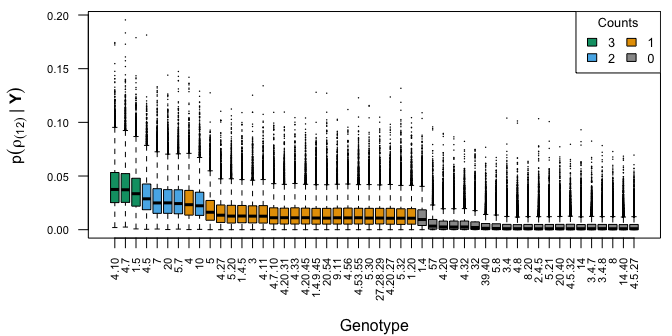

```r
rho.post <- fit0$rho[,1,]   # p(rho12 | Y)
# sort genotype counts by decreasing order
rho.count <- colSums(Xsuff$tab[popId,])
rho.ord <- order(colMeans(rho.post), decreasing = TRUE)

# plot
nbxp <- 50            # number of genotypes for which to make boxplots
clrs <- c("#999999", "#E69F00", "#56B4E9", "#009E73", "#F0E442", "#0072B2",
          "#D55E00", "#CC79A7")
rho.ct <- rho.count[rho.ord[1:nbxp]]
rho.lgd <- unique(sort(rho.ct))
rho.box <- rho.post[,rho.ord[1:nbxp]]
par(mar = c(5,4.5,.5,.5)+.1, cex.axis = .7)
boxplot(x = rho.box,
        las = 2, col = clrs[rho.ct+1], pch = 16, cex = .2)
title(xlab = "Genotype", line = 4)
title(ylab = expression(p(bold(rho)[(12)]*" | "*bold(Y))))
legend("topright", legend = rev(rho.lgd), fill = rev(clrs[rho.lgd+1]),
       title = "Counts", ncol = 2, cex = .8)
```

### Calculating the Posterior P-Value

This is calculated analogously to the bootstrapped p-value, by generating $M$ contingency tables with $\boldsymbol Y_k^{(m)} \stackrel{\textrm{ind}}{\sim}\textrm{Multinomial}(N_k, \boldsymbol \rho_{12}^{(m)}$, $m = 1, \ldots, M$. However, for each contingency table, the common probability vector $\boldsymbol \rho_{12}^{(m)}$ is different, corresponding to a random draw from $p(\boldsymbol \rho_{12} \mid \boldsymbol Y, H_0)$. The test statistic $T^{(m)}$ is then calculated and we have
$$\textrm{p}_\textrm{v}^{\textrm{post}}= \frac 1 M \sum_{m=1}^M \delta(T^{(m)} \ge T_{\textrm{obs}}).$$
$\textrm{p}_\textrm{v}^{\textrm{post}}$ is calculated with **MADPop** as follows:

```r
system.time({
  T.post <- UM.eqtest(N1 = N1, N2 = N2, p0 = rho.post, nreps = 1e4,
                      verbose = FALSE)
})
```

```
##    user  system elapsed
##   1.427   0.109   1.539
```

```r
# posterior p-value
pv.post <- rowMeans(t(T.post) >= T.obs)
```

We can now compare the three types of p-values (asymptotic, bootstrapped, posterior) for each test statistic ($\mathcal X$ and $\Lambda$):

p-value ($\times100\%$)

|  | Asymptotic | Bootstrap | Posterior |
| --- | --- | --- | --- |
| $\mathcal X$ | 33.0 | 0.61 | 13 |
| $\Lambda$ | 4.1 | 0.56 | 13 |

We see that $\textrm{p}_\textrm{v}^{\textrm{post}}$ is much more conservative than $\textrm{p}_\textrm{v}^{\textrm{boot}}$.

## Future Work

Here we used a completely unconstrained Multinomial model for the genotype counts, in the sense that the only restriction on $\boldsymbol \rho_k$ is that $\rho_{ki} \ge 0$ and $\sum_{i=1}^C \rho_{ki} = 1$. However, it is possible to impose genetic constraints such as Hardy-Weinberg equilibrium, preferential mating, etc., which effectively reduce the degrees of freedom of $\boldsymbol \rho_k$ below $C-1$. In this case, the closed-form likelihood $\mathcal L(\boldsymbol \alpha\mid \boldsymbol Y)$ is typically unavailable, but the **stan** code can easily be modified to sample from $p(\boldsymbol \alpha, \boldsymbol{\mathcal R}\mid \boldsymbol Y)$, where $\boldsymbol{\mathcal R}= (\boldsymbol \rho_1, \ldots, \boldsymbol \rho_K)$. We hope to feature some of these extensions to the basic Dirichlet-Multinomial model in the next version of **MADPop**.

## References

Minka, T.P. 2000. “Estimating a Dirichlet Distribution.” *Technical Report*. Massachusetts Institute of Technology. https://tminka.github.io/papers/dirichlet/minka-dirichlet.pdf.

Stan Development Team. 2016. “Rstan: The R Interface to Stan.” 2016. http://mc-stan.org.